[output not shown]

<sup>1</sup> Department of Dermatology, Venerology, and Allergology, Charité – Universitätsmedizin Berlin, corporate member of Freie Universität Berlin, Humboldt-Universität zu Berlin, and Berlin Institute of Health, Charitéplatz 1, 10117 Berlin,

<sup>2</sup> Department of Dermatology and Allergology, Klinikum der Universität München, Germany

<sup>3</sup> Department of Dermatology, Saarland University Hospital, Homburg/Saar, Germany

<sup>4</sup> Department of Dermatology, University Hospital Basel, Switzerland

**Corresponding author:** Prof. Dr. med. M. Worm margitta.worm@charite.de Phone: +49 30 450 529 005; Fax: +49 30 450 529 902

**Keywords:** anaphylaxis, adrenaline (epinephrine), beta-blockers, insect venom allergy, yellow-jacket

# Abstract

The data show that 68.2% of all insect elicited cases were elicited by yellow jackets, followed by bees (20.5%). The insect venom elicited cases occurred mostly in outdoor places (46%) patients’ homes (13.2%) or urban places (9.4%).

Patients who experienced insect-venom anaphylaxis were older (p < 0.0001), more often had concomitant mastocytosis (p < 0.0001) and cardiologic conditions (p < 0.0001) and females more often had concomitant thyroid diseases and less often suffered from a food allergy or atopic dermatitis.

# Introduction

# Methods

The European Anaphylaxis Registry [@Grabenhenrich2016] database from March 2019 was searched for anaphylaxis cases elicited by insect’s venom. The flowchart in figure @ref(fig:flowchart) represents the detailed case-selection process.

The final database consisted of 3612 cases of insect elicited anaphylaxis from 11 countries. Severe reactions were identified based on the definition by NIAID/FAAN [@Sampson2006] or as Ring and Messmer Scale - grades III and IV) and presented with significant hypoxia, hypotension, confusion, collapse and loss of consciousness, or incontinence. We compared the frequency of various elicitors, symptoms, and factors known to increase the risk of severe anaphylaxis [@Worm2018] in both groups. We evaluated symptoms, management and risk factors of insect elicited cases in comparison to other known triggers of anaphylaxis.

We observed a significant difference in the clinical features of insect anaphylaxis in children and adults. The younger population significantly less often had concomitant conditions (i.e. DM, HT, malignant diseases and mastocytosis), and more often presented with atopic dermatitis, rhinitis, and asthma. Therefore, we decided to adjust the analysis for age and sex to reduce the comparison bias. When comparing the management of both types of anaphylaxis we also matched the control group according to severity.

The statistical analysis was performed in the R Statistical Package [@R]. A simple comparison of categorical variables was performed using either Chi<sup>2</sup> test or Fisher’s exact test (where the number of observation in a bin was less than 10), continuous variables were analyzed using Mann-Whitney U test. We defined statistical significance as α = 0.05. Data along with the analysis script can be accessed online at https://github.com/wolass/venomanaphylaxiscompendium.

# Results

## Temporal distribution of anaphylaxis cases by elicitor.

Insect venom elicited anaphylaxis in contrast to other elicitors showed a significant seasonal fluctuation and was most frequently reported from May till October. Their proportion to other cases during the summer seasons reached 60% and was as under 1% of cases during winter. Yellow-jacket was the most prominent IVA-causing insect reported in these cases followed by bees. The IVA causing insects differed in European countries with hornets being more prominent in the south of Europe. IVA was more frequent in adults and seniors when compared to children and young adults. (Fig @ref(fig:insectstime)).

## Symptoms

The pattern of organ involvement showed similarities in gastrologic, skin and respiratory symptoms, and did not differ in the fraction of elevated baseline serum tryptase. Although, less atopic diseases were seen in patients undergoing IVA (Fig @ref(fig:figsymptoms)C).

Severe reactions were more prevalent in adults in comparison to children under 18, and in IVA cases vs other elicitors (Fig. @ref(fig:figsymptoms)D). There were no differences in severity between insect species.

## Management

Patients who underwent IVA significantly less often received adrenaline treatment than in other adrenaline cases (0.3653846, 0.1346154, 0.3269231, 0.1730769, p < 0.001). After adjusting both groups for similar age, sex and severity distribution - the difference in adrenaline use was still significant irrespective of the route of administration. Antihistaminic drugs, on the other hand, were given more often in cases of IVA when compared to non-IVA.

IVA was most often treated with corticosteroids and antihistamines (significantly more frequent than in other anaphylaxis cases). On the other hand adrenaline, beta-2 mimetics and oxygen were given more often in non-IVA.

We discovered clusters of symptoms and therapy modes. In IVA patients urticaria, and cardiologic symptoms (cardiac arrest, hypotension, loss of consciousness), as well as respiratory distress, were treated more similarly than gastroenterologic symptoms (Fig. @ref(fig:adrenalineuse)C). Therapy that was usually used together was dependent on the symptom profile and consisted of AAI, i.v. adrenaline in multiple doses, pure oxygen inhalation, an initial dose of antihistamines, and beta 2 agonists. Corticosteroids, volume replacement and i.v. beta2 agonists formed another therapy mode.

The most differences in the therapy of IVA vs. other forms of anaphylaxis was observed in the frequency of inhaled beta2-agonists and antihistamines (probably because these are not available for the IVA patients, but atopic patients use them regularly) (Fig. @ref(fig:adrenalineuse)B).

## Co-factors

Although the physical exercise was more often related to IVA than other triggers of anaphylaxis - it was not predictive of the severity of a reaction in these patients.

Concomitant use of ACE-I did not correlate with reaction severity measured in ANAscore and VAS scales. It was however more often associated with cardiac arrests in both IVA and other-triggers anaphylaxis (Fig. S@ref(figs:acei)).

Beta-blockers use was associated with higher severity scores in VAS and ANAscore and with cardiac arrest, chest pain. Especially arrhythmia was more frequently reported in patients undergoing IVA with concomitant beta-blockers.

Baseline serum tryptase correlated with the severity of reactions and especially in the Ring and Messmer scale was more prominently increasing risk of severe anaphylaxis in IVA patients than in other cases (Fig. @ref(fig:figcofactors)B and S@ref(figs:tryp)). In the VAS scale, this did not show as significant, but it did in all the other severity scales. We decided to use Tryptase cut off value of 8 ng/ml (Fig. S@ref(figs:tryp2)). We saw that cases with cardiac arrest were associated with increased tryptase over 8 ng/ml and this proportion was higher in IVA when compared to other elicitors. Loss of consciousness was also associated with increased tryptase levels but only in patients with IVA (Fig. @ref(fig:figcofactors)C).

We compared the Hymenoptera species which was responsible for triggering IVA according to the severity of the reaction. Patients matched according to sex and age has similar reactions to bees and yellow-jackets (in Brown and Ring and Messmer scales). In ANAscore - yellow jacket stings were linked to a slightly more severe reaction. This data, however, is not comparable to the refractory anaphylaxis cases as refractory anaphylaxis seems to be a distinct phenotype.

# Discussion

Cardiologic symptoms and hypotensive collapse might be associated with venom anaphylaxis due to the vaso-vagal reflex. As seen in patients undergoing blood sampling needles (and probably also insect stings) may elicit a hypotensive response due to extreme emotional distress with bradycardia, limiting the blood flow to the brain and causing syncope. This mechanism may contribute to the ongoing histamine-induced vasodilatation and may worsen the symptoms of an allergic reaction.

# Conclusion

# Acknowledgements

# References

# Figures

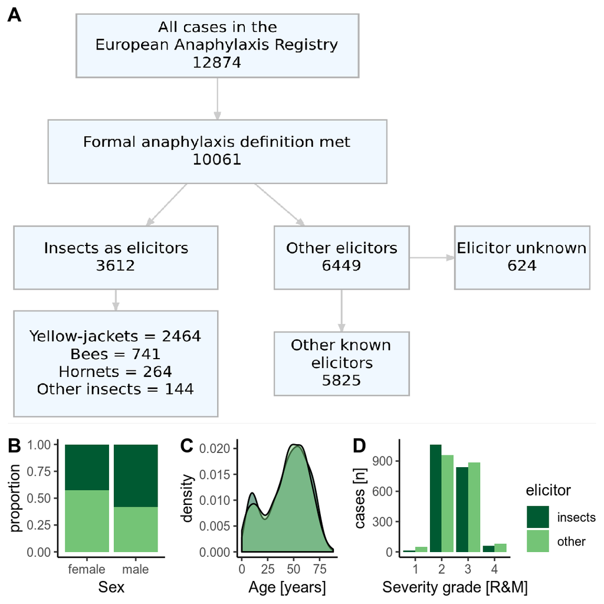

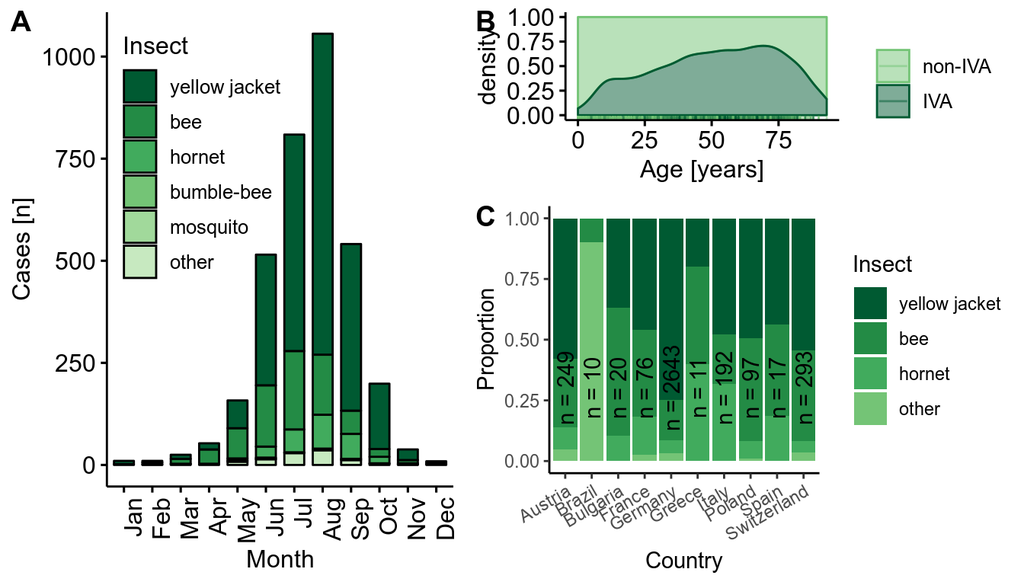

A: Proportion of anaphylaxis cases elicited by specific insects according to the month in which the reaction occurred. Less frequent insects were grouped together as ‘other’. B: The proportion of insect elicited cases to cases elicited by other triggers considering the patient’s age. C: Geographical differences in the most common elicitors of IVA. Countries which reported less than 10 cases of anaphylaxis due to insect venom were not illustrated in this figure.

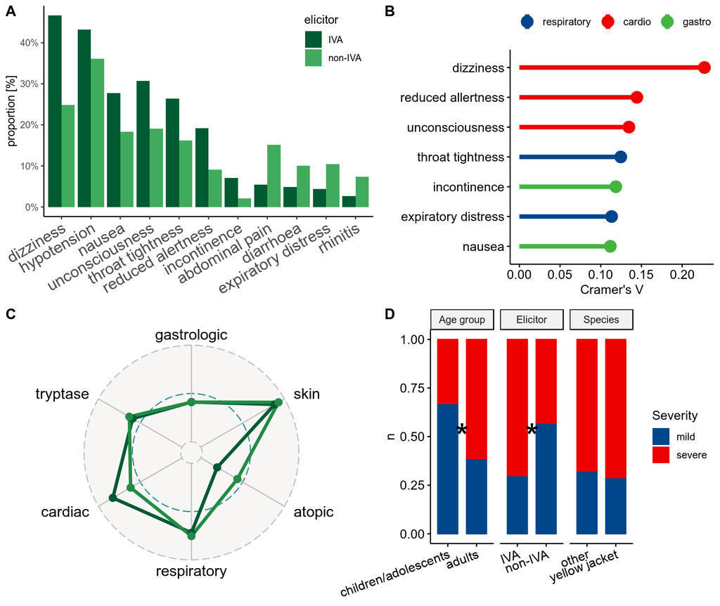

Symptoms of insect venom anaphylaxis (IVA) compared to other elicitors

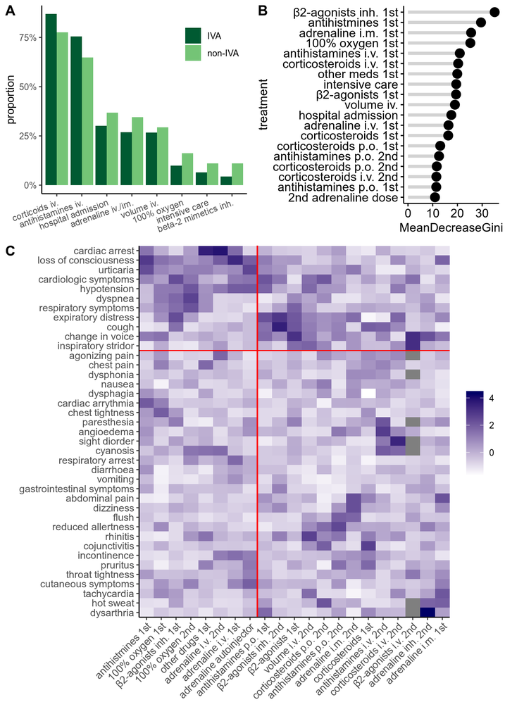

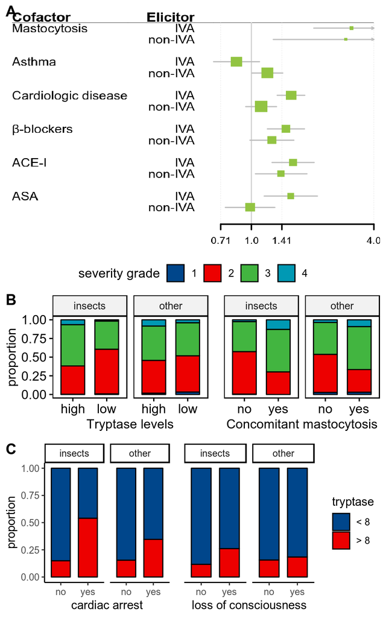

Cofactors of insect venom anaphylaxis ad their relationship to severity of a reaction

# Supplementary Figures

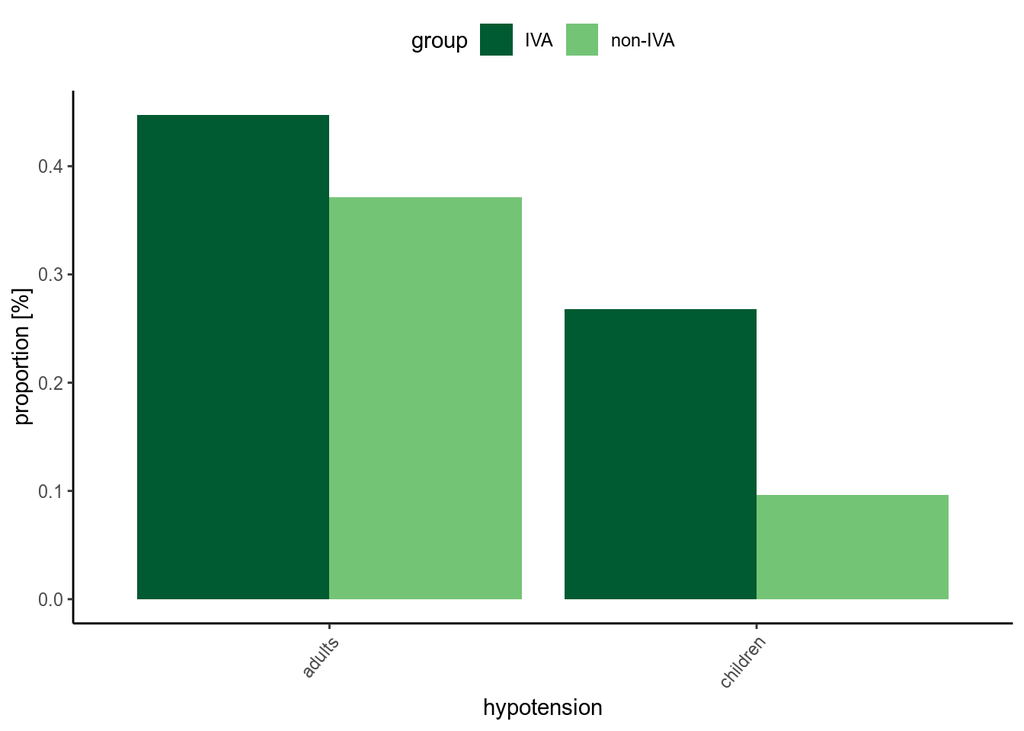

Hypotension in IVA of kids

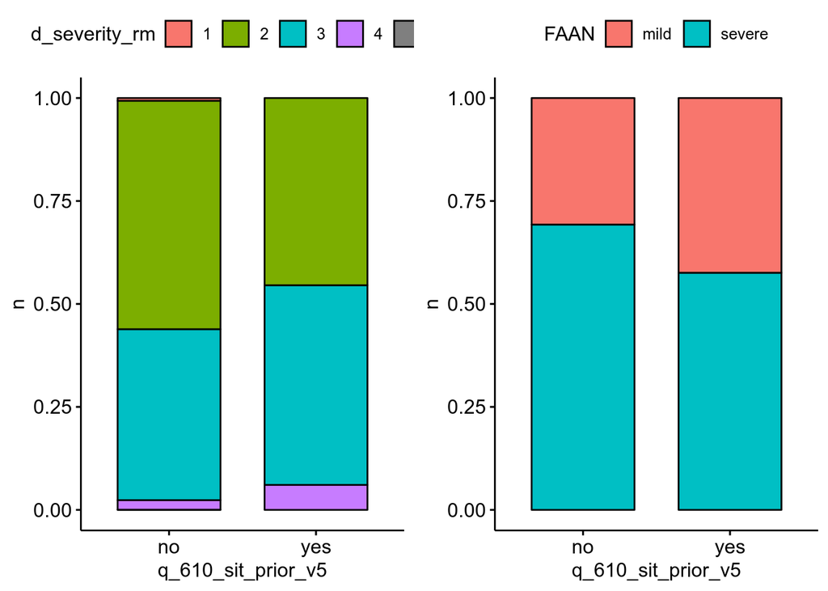

| variableName | counts_1 | counts_2 | fraq_1 | fraq_2 | pval |
| --- | --- | --- | --- | --- | --- |
| q_410_prev_v5 | 1299 | 2060 | 0.5638021 | 0.7703815 | 0 |
| q_410_cur | 1879 | 2548 | 0.5544408 | 0.7437245 | 0 |
| q_410_rhinitis_prev_v5 | 324 | 858 | 0.1406861 | 0.3208676 | 0 |
| q_410_rhinitis_cur | 440 | 984 | 0.1298318 | 0.2872154 | 0 |
| q_410_asthma_prev_v5 | 195 | 551 | 0.0846722 | 0.2060583 | 0 |
| q_410_asthma_cur | 277 | 681 | 0.0817350 | 0.1987741 | 0 |
| q_410_foodallergy_prev_v6 | 61 | 341 | 0.0355685 | 0.1613819 | 0 |
| q_410_foodallergy_cur_v6 | 57 | 345 | 0.0316140 | 0.1574623 | 0 |
| q_4211_exercise | 1164 | 649 | 0.3773096 | 0.1943696 | 0 |
| q_422_stress | 110 | 363 | 0.0304625 | 0.1004705 | 0 |

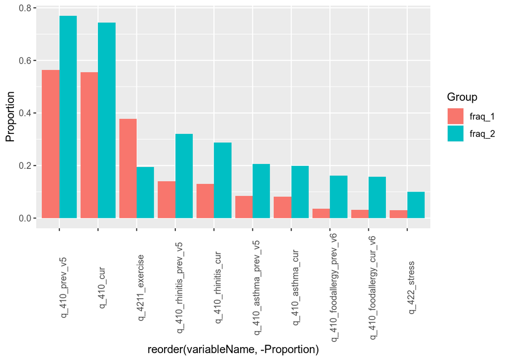

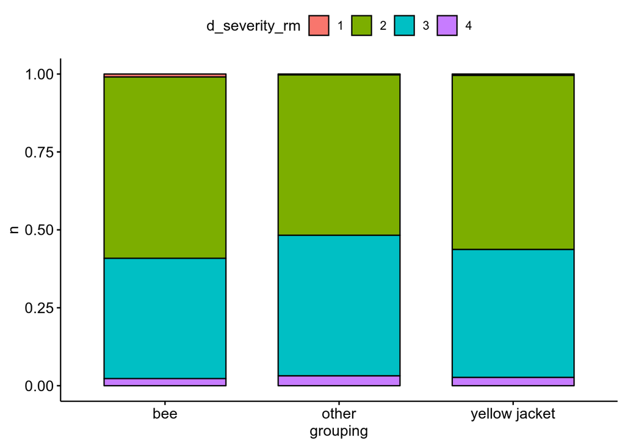

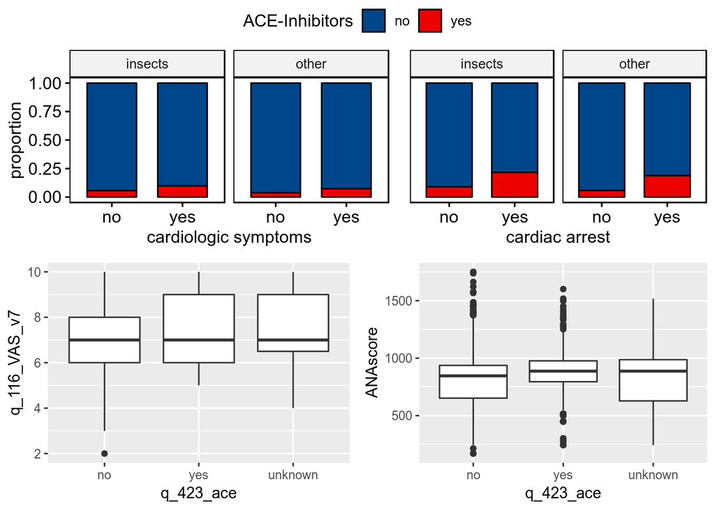

```
#>
#>  Wilcoxon rank sum test with continuity correction
#>
#> data:  q_116_VAS_v7 by q_423_beta
#> W = 45631, p-value = 0.002128
#> alternative hypothesis: true location shift is not equal to 0
```

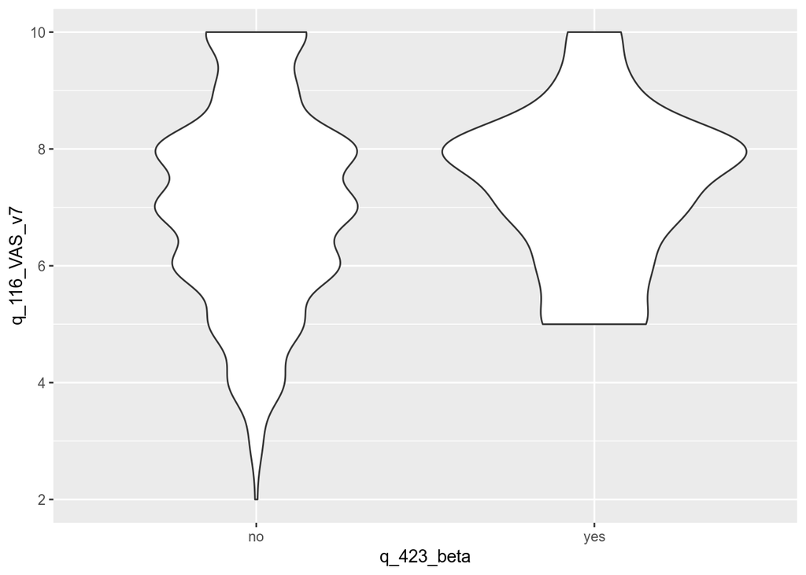

```
#> # A tibble: 2 x 3
#>   q_423_beta medianVAS IQRVAS
#>   <chr>          <dbl>  <dbl>
#> 1 no                 7    2
#> 2 yes                8    1.5
#>
#>  Wilcoxon rank sum test with continuity correction
#>
#> data:  ANAscore by q_423_beta
#> W = 599560, p-value = 0.0004057
#> alternative hypothesis: true location shift is not equal to 0
```

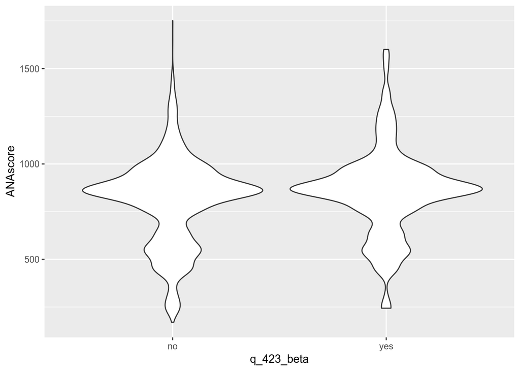

```
#> # A tibble: 2 x 3
#>   q_423_beta medianANAscore IQRANAscore
#>   <chr>               <dbl>       <dbl>
#> 1 no                    846        285
#> 2 yes                   870        182.
```

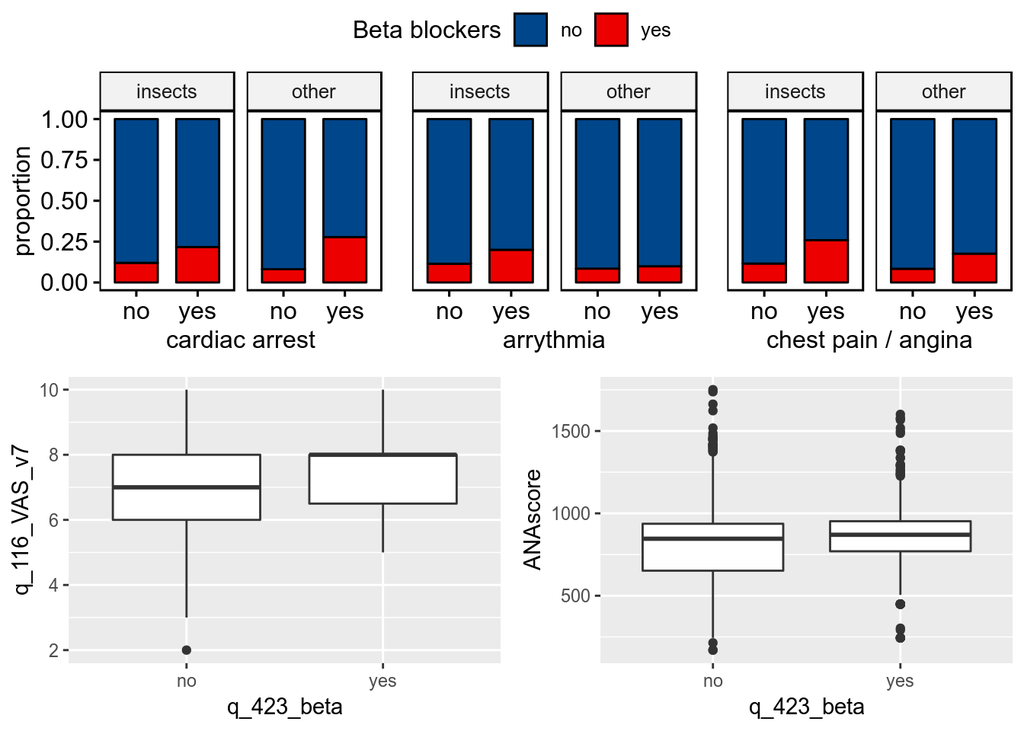

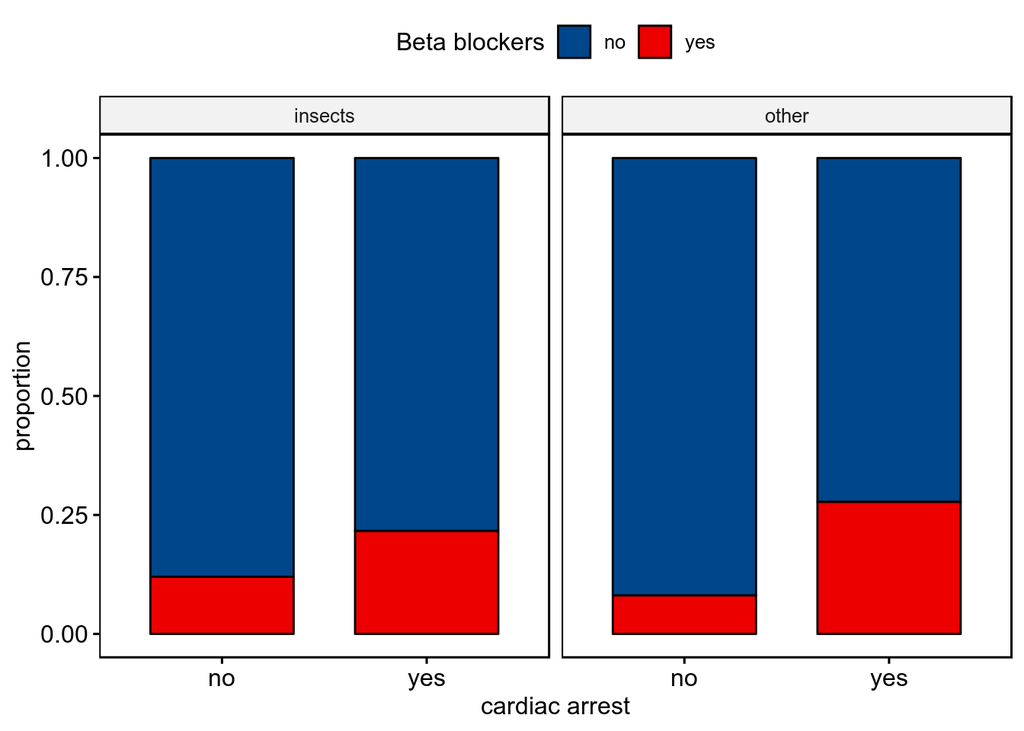

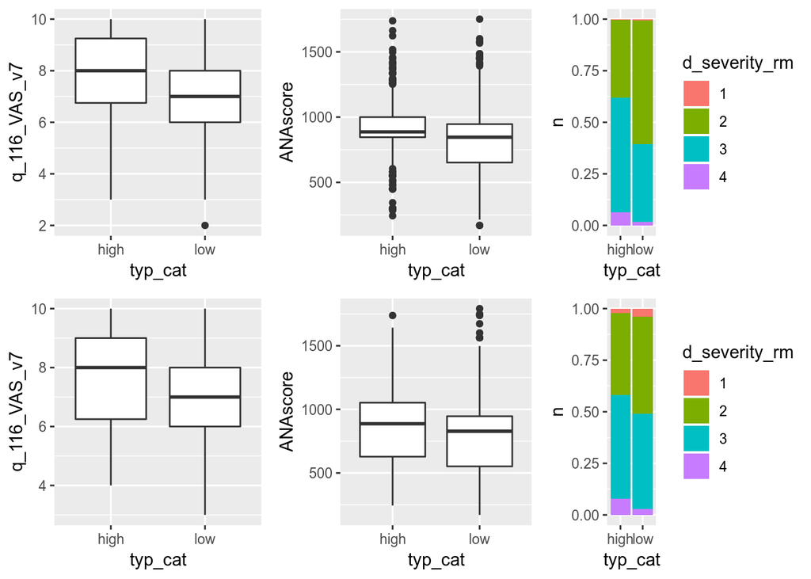

Severity of anaphylaxis is influenced by baseline serum tryptase levels with the cut off of 8 ng/ml in IVA (top row) vs other anaphylaxis cases

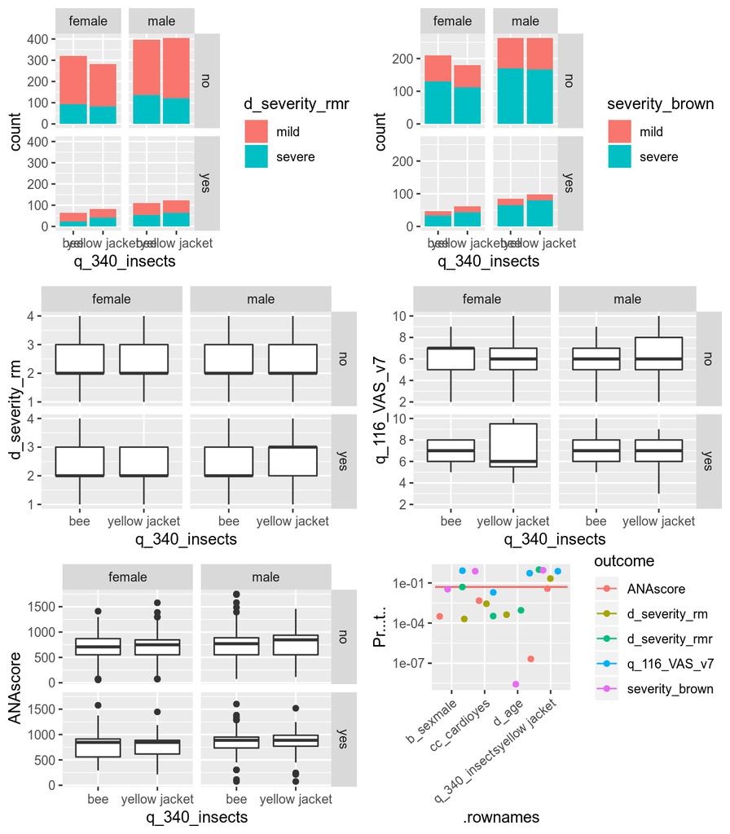

Models of severity and the influence of jellow jacket vs bees

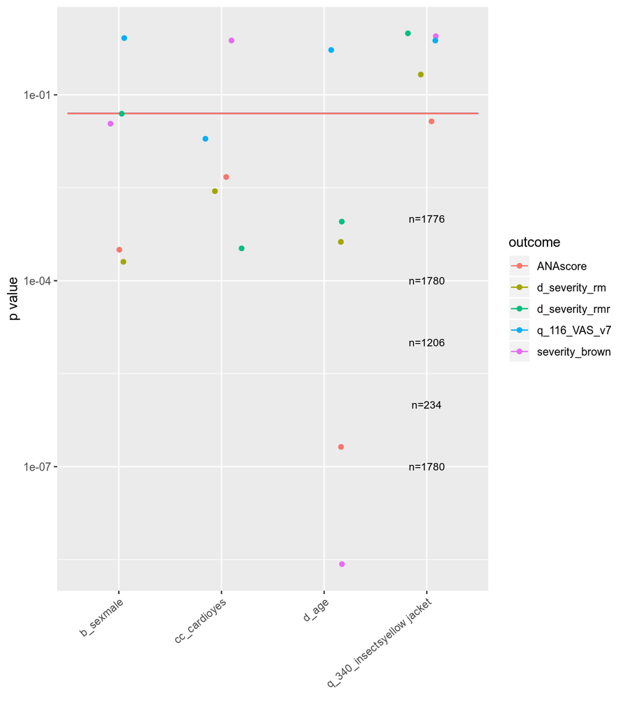

Models of severity and the influence of jellow jacket vs bees

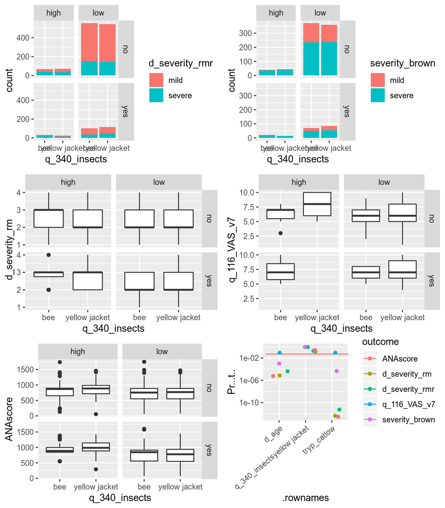

tryptase cut off value plot